# R Notebook

# general settings

## working directory

```r
working.dir = "/home/jyu/rstudio/"

ms_dir = paste0(working.dir,"/IPF_manuscript/manuscriptV3/figures")
ms_date = "20230921"

rm(load_packages)
```

## color

### IPF stages

```r
stage_color = c("Control" = "grey",
                "Early-IPF" = "#076B94",
                "Advanced-IPF" = "#E0B32D"
                )
```

## mac_label

```r
mac_label = c("0" = expression(Alveolar*"-"*M*phi1*(0)),
                             "4_0" = "Monocyte(4_0)",
                             "4_1" = expression(RNASE1^"+"*M*phi1*(4*"_"*1)),
                             "4_2" = expression(SPP1^"+"*M*phi1*(4*"_"*2)),
                             "6" = expression(S100A11^"+"*M*phi1*(6)),
                             "7" = expression(MKI67^"+"*M*phi1*(7*","*13*","*20)),
                             "8" = expression(CXCL10^"+"*M*phi1*(8)),
                             "10" = expression(TNFAIP6^"+"*M*phi1*(10)),
                             "11" = expression(NEAT1^"+"*M*phi1*(11)),
                             "13" = expression(MKI67^"+"*M*phi1*(7*","*13*","*20)),
                             "20" = expression(MKI67^"+"*M*phi1*(7*","*13*","*20)))
```

# load saved object

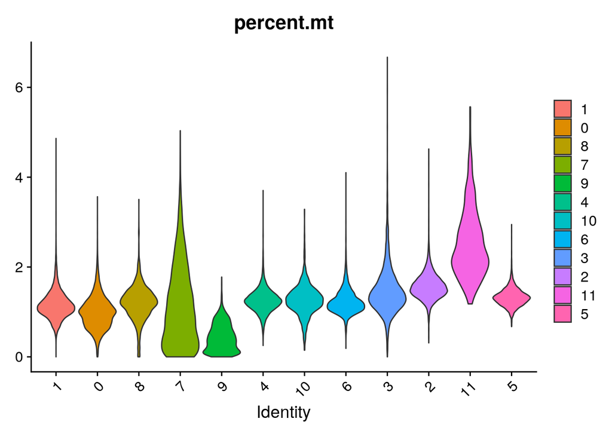

```r
ghent_seu = readRDS(file = paste0(working.dir,"/scRNA_processed/230306_Ghent_COVID_CITEseq_Annotated_spp1predicted.RDS"))

Idents(ghent_seu) = "seurat_clusters"

ghent_seu[["percent.mt"]] = PercentageFeatureSet(ghent_seu,pattern = "MT-",assay = "originalexp")

VlnPlot(ghent_seu,features = "percent.mt",pt.size = 0)
```

```r
# ghent_seu = RUN
```

## overlay ipfmac database

```r
# ghent_seu = readRDS(paste0(working.dir,"/scRNA_processed/230306_Ghent_COVID_CITEseq_Annotated.RDS"))
# run1to4_ck_ipf_n_copd_ck_singlelive_mac = readRDS(paste0(working.dir,"/scRNA_processed/run1to4_ck_ipf_n_copd_ck_rpca_subcluster_singlelivemac.rds"))
#
# ## rename meta data colnames
# colnames(ghent_seu@meta.data)[48:49] = c("umap1_old","umap2_old")
#
# # Double check which assay your datasets are in, I think RNA assay is probably best
# DefaultAssay(ghent_seu) <- "GEX"
# DefaultAssay(run1to4_ck_ipf_n_copd_ck_singlelive_mac) <- "integrated"
#
# # find transfer anchors
# Transfer.anchors <- FindTransferAnchors(reference = run1to4_ck_ipf_n_copd_ck_singlelive_mac, query = ghent_seu,
#                                         dims = 1:30)
# # generate prediction scores
# predictions <- TransferData(anchorset = Transfer.anchors, refdata = run1to4_ck_ipf_n_copd_ck_singlelive_mac$subcluster,
#                             dims = 1:30)
# # add prediction scores to metadata of your query object
# ghent_seu <- AddMetaData(ghent_seu, metadata = predictions)
#
# write.csv(ghent_seu@meta.data,file = paste0(working.dir,"ghent_annotated_by_ipfmac.csv"))
#
# saveRDS(ghent_seu,file = paste0(working.dir,"/scRNA_processed/230306_Ghent_COVID_CITEseq_Annotated_spp1predicted.RDS"))
```

# figure 4B

```r
Idents(ghent_seu) = "seurat_clusters"

Idents(ghent_seu) = factor(Idents(ghent_seu),levels = c(6,1,10,2,5,0,3,4,9,7,8,11))

DefaultAssay(ghent_seu) = "ADT"

pdf(file = paste0(ms_dir,"/fig4b.ghent_cite_antibody_",ms_date,".pdf"),paper = "a4",width = 2.5,height = 3.5)

# DoHeatmap(tmp_seu,features = c("Antibody-CD10","Antibody-CD169","Antibody-CD206"),slot = "data",group.by = "seurat_clusters",angle = 90)+
#   # scale_fill_gradientn(colours  = c("#a8dadc","white","#9d0208"))+
#   guides(color="none")

p = DotPlot(ghent_seu,features = c("Antibody-CD10","Antibody-CD169","Antibody-CD206"))

p = p +
  scale_y_discrete(labels = c(
    "6" = "6:Monocyte",
                         "1" = expression(1*":"*RNASE1^"+"*M*phi1),
                         "10" = expression(10*":"*SPP1^"+"*M*phi1),
                         "2" = expression(2*":"*Alveolar*"-"*M*phi1),
                         "5" = expression(5*":"*Alveolar*"-"*M*phi1),
                         "0" = expression(0*":"*CXCL10^"+"*M*phi1),
                         "3" = expression(3*":"*CXCL10^"+"*M*phi1),
                         "4" = expression(4*":"*APOE^"+"*M*phi1),
                         "9" = expression(9*":"*APOE^"+"*M*phi1),
                         "7" = expression(7*":"*FCGR3B^"+"*M*phi1),
                         "8" = "8:DC",
                         "11" = "11:Dead cell"
  ))+

  scale_x_discrete(labels = c(
    "Antibody-CD10" = "CD10",
    "Antibody-CD169" = "CD169",
    "Antibody-CD206" = "CD206"
  ))+
  theme_classic()+
  theme(axis.text.x = element_text(size = 8),
        axis.text.y = element_text(size = 8),
        axis.title = element_blank(),
        legend.text = element_text(size = 8,colour = "black"),
        legend.title = element_text(size = 8,colour = "black"),
        panel.border = element_rect(color = "black",size=0.8,fill = NA),
        legend.position = "bottom",
        legend.box = "vertical",
        legend.justification = c(0,1),
        legend.margin = margin(0,20,0,-50))+
  guides(size = guide_legend(order = 2,direction = "horizontal",title = "% of exp. cells"),
         color = guide_colorbar(order = 2,direction = "horizontal",title = "Antibody expression",barwidth = 3,barheight = 0.3))

plot(p)
dev.off()
```

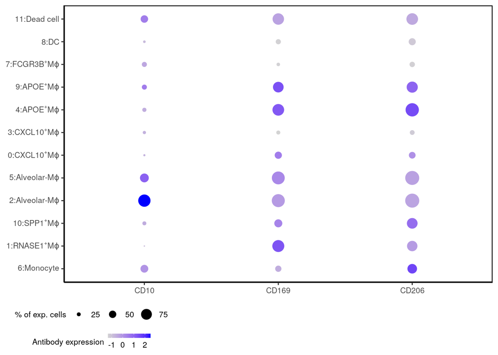

```r
p
```

```r
rm(tmp_seu,p)
```

# figure 4C

```r
pdf(file = paste0(ms_dir,"/fig4c.ghent_cite_FLOR2_ALCAM_",ms_date,".pdf"),paper = "a4",width = 4,height = 1.5)


DefaultAssay(ghent_seu) = "GEX"
p = VlnPlot(ghent_seu,features = c("FOLR2","ALCAM"),pt.size = 0) &
  theme(axis.title.x = element_blank(),
        axis.title.y = element_text(size = 8),
        legend.position = "none",
        axis.text.y  = element_text(size = 8),
        axis.text.x  = element_text(size = 8,angle = 0,hjust = 0.5),
        plot.title = element_text(size=8))

plot(p)

dev.off()
```

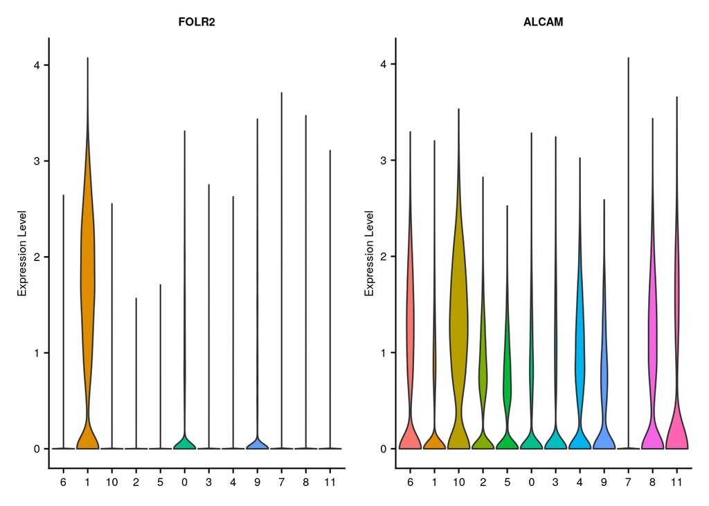

```r
p
```

```r
rm(p)
```

R version 4.1.3 (2022-03-10) Platform: x86_64-pc-linux-gnu (64-bit) Running under: Ubuntu 20.04.4 LTS

Matrix products: default BLAS/LAPACK: /usr/lib/x86_64-linux-gnu/openblas-pthread/libopenblasp-r0.3.8.so

locale: [1] C

attached base packages: [1] splines stats4 stats graphics grDevices utils datasets [8] methods base

other attached packages: [1] DOSE_3.20.1 org.Mm.eg.db_3.14.0 org.Hs.eg.db_3.14.0  
[4] AnnotationDbi_1.56.2 IRanges_2.28.0 S4Vectors_0.32.4  
[7] Biobase_2.54.0 BiocGenerics_0.40.0 clusterProfiler_4.2.2 [10] biomaRt_2.50.3 DescTools_0.99.50 data.table_1.14.2  
[13] future_1.24.0 plotly_4.10.0 VGAM_1.1-6  
[16] Matrix.utils_0.9.8 Matrix_1.4-0 tidyr_1.2.0  
[19] dplyr_1.0.8 reshape2_1.4.4 umap_0.2.8.0  
[22] stringr_1.4.0 SeuratObject_4.0.4 Seurat_4.1.0  
[25] useful_1.2.6 ggplot2_3.3.5 cowplot_1.1.1  
[28] readr_2.1.2